# Libraries

```python
import pandas as pd
import numpy as np
import json
import matplotlib.pyplot as plt
import seaborn as sns

from statsmodels.tsa.seasonal import seasonal_decompose

# Feature Engineering and data prep.
from sklearn.model_selection import cross_val_score, train_test_split
from sklearn.impute import SimpleImputer
from sklearn.pipeline import make_pipeline, Pipeline
from sklearn.compose import ColumnTransformer
from sklearn.preprocessing import OneHotEncoder,StandardScaler, MinMaxScaler

# Regression Models to Test
from sklearn.tree import DecisionTreeRegressor
from sklearn.ensemble import RandomForestRegressor, GradientBoostingRegressor
from lightgbm import LGBMRegressor
from sklearn.neighbors import KNeighborsRegressor

# Metrics
from sklearn.metrics import mean_absolute_error,mean_absolute_percentage_error,r2_score
```

# Data: Load and Transform

```python
df = pd.read_csv('pros_rates_voice.csv')
```

```python
df.dropna(inplace=True)
```

```python
df.info()
```

```
<class 'pandas.core.frame.DataFrame'>
Int64Index: 12207 entries, 0 to 12210
Data columns (total 7 columns):
 #   Column             Non-Null Count  Dtype
---  ------             --------------  -----
 0   user_id            12207 non-null  int64
 1   modified           12207 non-null  object
 2   subcategory        12207 non-null  object
 3   trusted            12207 non-null  int64
 4   status_submission  12207 non-null  object
 5   seed_data          12207 non-null  object
 6   language_id        12207 non-null  object
dtypes: int64(2), object(5)
memory usage: 762.9+ KB
```

```python
df.isnull().sum()
```

```
user_id              0
modified             0
subcategory          0
trusted              0
status_submission    0
seed_data            0
language_id          0
dtype: int64
```

```python
df.sample(5)
```

|  | user_id | modified | subcategory | trusted | status_submission | seed_data | language_id |
| --- | --- | --- | --- | --- | --- | --- | --- |
| 1526 | 1526 | 2022-01-26T13:32:04 | voice_over | 1 | accepted | {"50000":{"time":"21600","cost":"5000.00","uni... | vulcan |
| 2628 | 2628 | 2021-02-04T00:59:13 | voice_over | 1 | test_project_failed_rejection | {"50000":{"time":null,"cost":"1200","units":"5... | vulcan |
| 6134 | 6134 | 2022-04-27T21:56:34 | voice_over | 1 | accepted | {"50000":{"time":"0","cost":"750","units":"500... | vulcan |
| 1848 | 1848 | 2020-03-11T19:04:19 | voice_over | 1 | test_project_failed_timing | {"50000":{"time":null,"cost":"2000","units":"5... | simlish |
| 8820 | 8820 | 2022-05-10T00:08:44 | voice_over | 1 | test_project_failed_timing | {"50000":{"time":null,"cost":"12000","units":"... | simlish |

```python
df.seed_data.sample(3)
```

```
11715    {"50000":{"time":null,"cost":"3375","units":"5...
6179     {"50000":{"time":null,"cost":"1000","units":"5...
7911     {"50000":{"time":null,"cost":"1000","units":"5...
Name: seed_data, dtype: object
```

## Creating DF from seed_data column -> df_prices

Creating dataset containing informations from seed_data(json).

```python
"""
From seed_data creates a new dataframe preserving client_id according to corresponding prices
"""

clients = df.user_id.to_list()
prices = df.seed_data.to_list()

prices = [json.loads(x) for x in prices]

merge = [] # list of dataframes

for client, price in zip(clients, prices):

    #print(client)
    temp = pd.DataFrame(price.values())
    temp['user_id'] = client

    merge.append(temp)

df_prices = pd.concat(merge)
```

```python
df_prices.shape
```

```
(59903, 5)
```

```python
df_prices[['units', 'time','cost', 'costUSD']].isnull().sum()
```

```
units         0
time       6791
cost          0
costUSD       0
dtype: int64
```

```python
df_prices.info()
```

```
<class 'pandas.core.frame.DataFrame'>
Int64Index: 59903 entries, 0 to 4
Data columns (total 5 columns):
 #   Column   Non-Null Count  Dtype
---  ------   --------------  -----
 0   units    59903 non-null  object
 1   time     53112 non-null  object
 2   cost     59903 non-null  object
 3   costUSD  59903 non-null  object
 4   user_id  59903 non-null  int64
dtypes: int64(1), object(4)
memory usage: 2.7+ MB
```

```python
# strip whitespaces to not flag wrongly in contains \D  - not digit

df_prices['time'] = df_prices['time'].str.strip()

df_prices['time'].replace('',np.nan,inplace=True)

df_prices.loc[df_prices['time'].str.contains(r'\D',na=False),'time'] = np.nan
```

```python
df_prices[['units', 'time','cost', 'costUSD']] = df_prices[['units', 'time','cost', 'costUSD']].astype('float64')
```

## Join DFs

Join raw df with df_prices using client_id as key;

```python
df.subcategory.value_counts()
```

```
voice_over    12207
Name: subcategory, dtype: int64
```

```python
# Removing subcategory,without relevant information

df = df[['user_id', 'modified', 'trusted', 'status_submission', 'language_id']]
```

```python
df2 = df.merge(df_prices,how='left',on='user_id')
df2.sample(5)
```

|  | user_id | modified | trusted | status_submission | language_id | units | time | cost | costUSD |
| --- | --- | --- | --- | --- | --- | --- | --- | --- | --- |
| 5566 | 1143 | 2019-01-04T00:05:08 | 1 | test_project_failed_timing | simlish | 50.0 | 10.0 | 50.0 | 50.0 |
| 13032 | 2660 | 2019-12-06T22:05:59 | 1 | test_project_failed_timing | vulcan | 50000.0 | NaN | 3600.0 | 3600.0 |
| 37184 | 7586 | 2016-07-29T15:39:22 | 1 | attribute_submission_pending | simlish | 5000.0 | 180.0 | 500.0 | 500.0 |
| 12935 | 2640 | 2019-11-05T00:05:09 | 1 | test_project_failed_timing | simlish | 50.0 | 120.0 | 60.0 | 60.0 |
| 2644 | 546 | 2020-06-02T05:46:46 | 1 | test_project_failed_timing | simlish | 50000.0 | NaN | 250.0 | 250.0 |

```python
df2.to_csv('df_complete.csv',index=False)
```

# Exploratory Data Analysis

Pricing requirements:

- Model takes a combination of pricing attributes (language, complexity, etc) and project lengths and returns a price for any length > 0.
- Pros receive the reward they expect
- Bunny Studio keeps at least the 15% of the project price
- Fulfillment types also play a role in the pricing,however we will omit that.

*Take into account that each language should have differentiated pricing and that you should be able to have a price for any project between 1 and 50,000 words.*

```python
''' Receive an array and compute x,y to plot '''

def ecdf(data):

    import numpy as np
    """Compute ECDF for a one-dimensional array of measurements."""

    # Number of data points: n
    n = len(data)

    # x-data for the ECDF: x
    x = np.sort(data)

    # y-data for the ECDF: y
    y = np.arange(1, n+1)/ n

    return x, y

''' Given an x,y  from ecdf plots ecdf graphically'''

def ecdf_plot(x, y, xlabel='name of xlabel'):

    import matplotlib.pyplot as plt

    _ = plt.plot(x,y,marker='.',linestyle='none')
    _ = plt.xlabel(xlabel)
    _ = plt.ylabel('ECDF')
    plt.margins(0.02)
    plt.show()
```

## Numerical Data

```python
df_prices.describe().round()
```

|  | units | time | cost | costUSD | user_id |
| --- | --- | --- | --- | --- | --- |
| count | 59903.0 | 52591.0 | 59903.0 | 59903.0 | 59903.0 |
| mean | 10259.0 | 1905.0 | 4464.0 | 2795.0 | 6112.0 |
| std | 18850.0 | 5683.0 | 127707.0 | 99867.0 | 3526.0 |
| min | 5.0 | 0.0 | 0.0 | 0.0 | 0.0 |
| 25% | 50.0 | 20.0 | 25.0 | 20.0 | 3060.0 |
| 50% | 500.0 | 60.0 | 100.0 | 100.0 | 6116.0 |
| 75% | 5000.0 | 180.0 | 500.0 | 477.0 | 9164.0 |
| max | 50000.0 | 21600.0 | 9999999.0 | 9999999.0 | 12210.0 |

- It's possible see **units** in right range expected: 0 < units < 50000
- For **time** we can observe some 0 seconds, that may be wrong filled and at max 21600 seconds ( 6 hours );
- Both cost and cost USD has approximately same quartile ranges, with possible outliers, we will look just for costUSD;

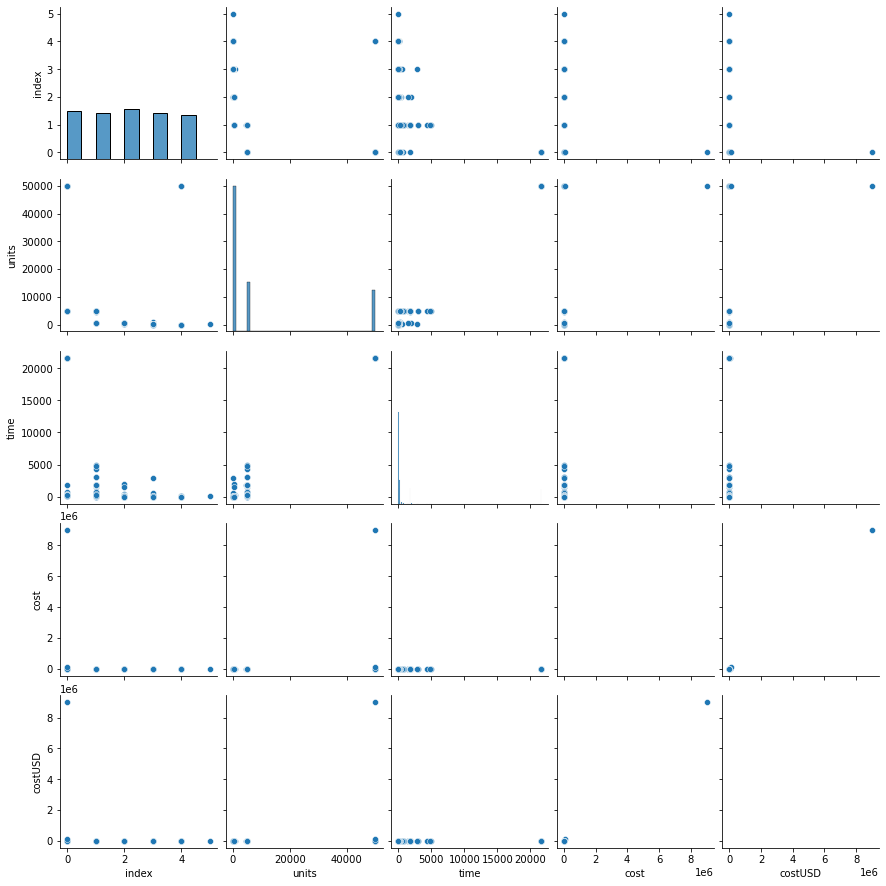

```python
sns.pairplot(df_prices[['units', 'time','cost', 'costUSD']].reset_index().sample(500))
```

### Time and Units

```python
# We will receive just 1 input from user: units(words) between 1 and 50000

df2[['time','units']].corr()
```

|  | time | units |
| --- | --- | --- |
| time | 1.000000 | 0.982167 |
| units | 0.982167 | 1.000000 |

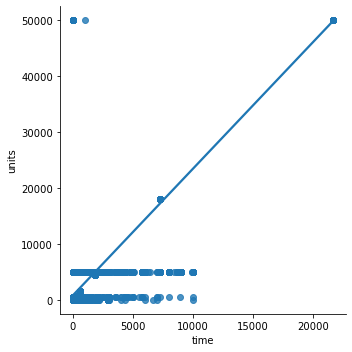

```python
sns.lmplot(data = df2, x='time', y='units')
```

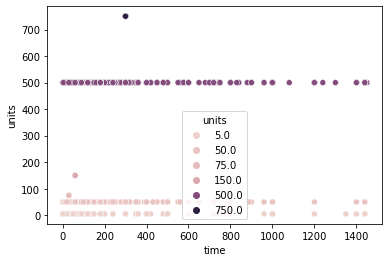

```python
sns.scatterplot(data = df2[(df2.time<1500)&(df2.units<1000)], x='time', y='units',hue='units')
```

Despite correlation bewteen units and time, it's not possible see a linear correlation in plot, so to use units and predict time a linear model it's not a good choice at the moment.

anscombe quartet - > https://www.researchgate.net/figure/Anscombes-quartet-highlights-the-importance-of-plotting-data-to-confirm-the-validity-of_fig2_280302159

It's important consider that user inputs is number of words(units), so to use time as a feature in the model we need to predict it or fill in someway.

### Costs

```python
df2.columns
```

```
Index(['user_id', 'modified', 'trusted', 'status_submission', 'language_id',
       'units', 'time', 'cost', 'costUSD'],
      dtype='object')
```

```python
df2[['cost', 'costUSD']].corr()
```

|  | cost | costUSD |
| --- | --- | --- |
| cost | 1.000000 | 0.785928 |
| costUSD | 0.785928 | 1.000000 |

It's just important to look at cost USD as target, the currency that the company uses, for a local pricing a good API to transform values for a PROS local currency should be enough.

```python
# Empirical cumulative distribution function for price USD - our target

x,y =  ecdf(np.array(df_prices.cost))
```

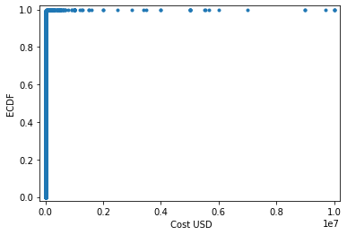

```python
ecdf_plot(x,y,' Cost USD')
```

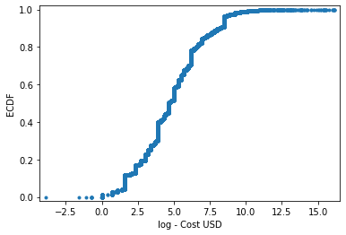

```python
ecdf_plot(np.log(x),y,'log - Cost USD')
```

```python
df_prices.cost.describe([0.75,0.8,0.85,0.9,0.95,0.99,1]).round()
```

```
count      59903.0
mean        4464.0
std       127707.0
min            0.0
50%          100.0
75%          500.0
80%          700.0
85%         1250.0
90%         3500.0
95%         5000.0
99%        25000.0
100%     9999999.0
max      9999999.0
Name: cost, dtype: float64
```

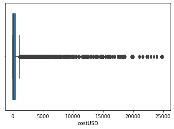

```python
sns.boxplot(df_prices.costUSD[df_prices.costUSD<25000])
```

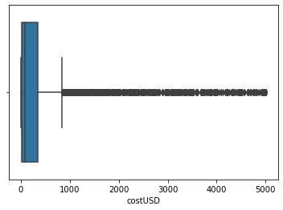

```python
sns.boxplot(df_prices.costUSD[df_prices.costUSD<=5000])
```

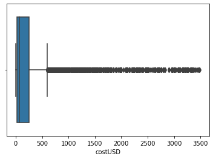

```python
sns.boxplot(df_prices.costUSD[df_prices.costUSD<3500])
```

```python
df_prices.costUSD[df_prices.costUSD==0]
```

```
4    0.0
0    0.0
1    0.0
2    0.0
3    0.0
0    0.0
1    0.0
2    0.0
3    0.0
4    0.0
Name: costUSD, dtype: float64
```

It will be necessary to exclude some outliers in feature engineering step.From Quartiles: 95%< prices are under 5k and 99%< prices under 25k.

### Correlations

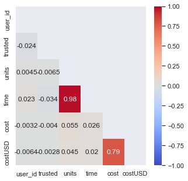

```python
mask = np.triu(np.ones_like(df2.corr(), dtype=np.bool));
sns.set(rc={'figure.figsize':(5,5)})
sns.heatmap(df2.corr(),annot=True, fmt='.2g',vmin=-1,vmax=1,center=0,cmap='coolwarm', mask=mask)
```

```python
df_prices = df_prices.loc[df_prices.cost <= 22000]
```

```python
x,y =  ecdf(np.array(df_prices.cost))
```

```python
df_prices = df_prices.loc[df_prices.cost <= 2000]
```

## Categorical Data

Frequency of categories and possible influence from them in pricing.

### Trusted

An identifier of how trusted is the pro. 0=Regular Pros 1=Very trustable Pros 2=Banned Pros

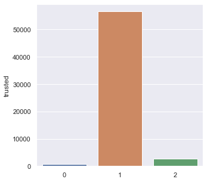

```python
sns.barplot(y=df2.trusted.value_counts(),x=df2.trusted.value_counts().index)
```

```python
df2.trusted.value_counts()
```

```
1    56540
2     2655
0      708
Name: trusted, dtype: int64
```

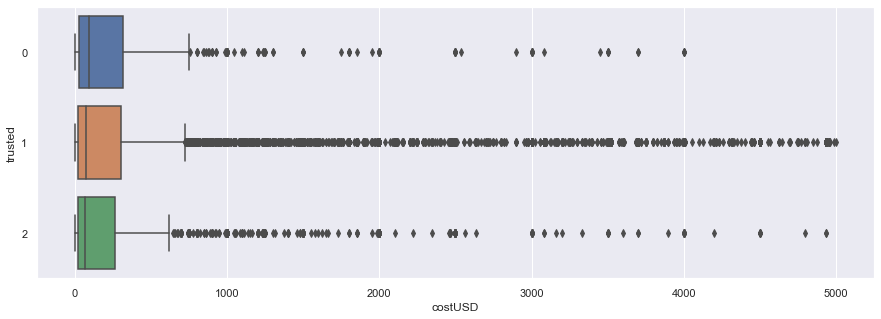

```python
plt.figure( figsize = ( 15, 5))
sns.boxplot(data=df2[df2.costUSD<5000],y='trusted',x='costUSD',orient='h')
```

```python
df2.groupby('trusted')['costUSD'].describe()
```

| trusted | count | mean | std | min | 25% | 50% | 75% | max |
| --- | --- | --- | --- | --- | --- | --- | --- | --- |
| 0 | 708.0 | 665.484364 | 2495.437747 | 0.50 | 25.0 | 100.0 | 387.90 | 50000.00 |
| 1 | 56540.0 | 2919.179533 | 102788.029098 | 0.00 | 20.0 | 100.0 | 493.48 | 9999999.00 |
| 2 | 2655.0 | 721.140629 | 4367.802684 | 0.77 | 20.0 | 75.0 | 300.00 | 123369.67 |

### Status_submission

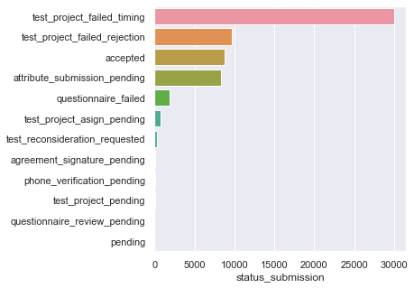

```python
sns.barplot(x=df2.status_submission.value_counts(),y=df2.status_submission.value_counts().index,orient='h')
```

```python
df2.status_submission.value_counts()
```

```
test_project_failed_timing        29982
test_project_failed_rejection      9694
accepted                           8759
attribute_submission_pending       8329
questionnaire_failed               1850
test_project_asign_pending          776
test_reconsideration_requested      271
agreement_signature_pending         115
phone_verification_pending           69
test_project_pending                 35
questionnaire_review_pending         18
pending                               5
Name: status_submission, dtype: int64
```

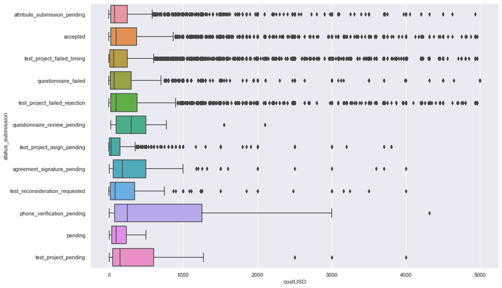

```python
plt.figure( figsize = ( 15, 10))
sns.boxplot(data=df2[df2.costUSD<5000],y='status_submission',x='costUSD',orient='h')
```

```python
df2.groupby('status_submission')['costUSD'].describe().sort_values('50%',ascending=False)
```

| status_submission | count | mean | std | min | 25% | 50% | 75% | max |
| --- | --- | --- | --- | --- | --- | --- | --- | --- |
| questionnaire_review_pending | 18.0 | 1036.721111 | 2547.871845 | 25.00 | 100.0000 | 300.000 | 647.5325 | 11000.00 |
| phone_verification_pending | 69.0 | 1114.843768 | 2164.999847 | 4.00 | 80.0000 | 250.000 | 1400.0000 | 14557.62 |
| agreement_signature_pending | 115.0 | 1061.542261 | 2311.070316 | 5.00 | 60.8400 | 200.000 | 800.0000 | 15000.00 |
| test_project_pending | 35.0 | 1443.218857 | 3917.869895 | 5.00 | 50.0000 | 200.000 | 678.5350 | 20000.00 |
| pending | 5.0 | 1141.000000 | 2165.965143 | 5.00 | 50.0000 | 150.000 | 500.0000 | 5000.00 |
| test_reconsideration_requested | 271.0 | 1019.347860 | 3424.710589 | 0.02 | 24.7300 | 148.720 | 500.0000 | 50000.00 |
| test_project_failed_rejection | 9694.0 | 1506.411072 | 11760.640436 | 0.01 | 25.0000 | 123.370 | 500.0000 | 500000.00 |
| accepted | 8759.0 | 892.419017 | 5660.870969 | 0.06 | 25.0000 | 100.000 | 493.4800 | 306600.00 |
| test_project_failed_timing | 29982.0 | 3808.930515 | 126783.954508 | 0.00 | 16.0000 | 90.000 | 500.0000 | 9999999.00 |
| attribute_submission_pending | 8329.0 | 2241.473316 | 101526.367824 | 0.00 | 24.7900 | 84.300 | 275.0000 | 9000000.00 |
| questionnaire_failed | 1850.0 | 5205.998719 | 121617.470766 | 0.01 | 17.3775 | 78.705 | 350.0000 | 5000000.00 |
| test_project_asign_pending | 776.0 | 2534.211224 | 27760.903830 | 0.02 | 7.0000 | 40.000 | 200.0000 | 500000.00 |

### Language

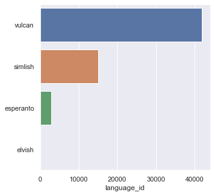

```python
sns.barplot(x=df2.language_id.value_counts(),y=df2.language_id.value_counts().index,orient='h')
```

```python
df2.language_id.value_counts()
```

```
vulcan       41925
simlish      15077
esperanto     2856
elvish          45
Name: language_id, dtype: int64
```

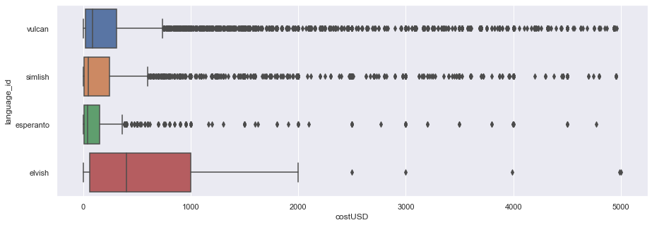

```python
plt.figure( figsize = ( 15, 5))
sns.boxplot(data=df2[df2.costUSD<5000],y='language_id',x='costUSD',orient='h')
```

```python
df2.groupby('language_id')['costUSD'].describe()
```

| language_id | count | mean | std | min | 25% | 50% | 75% | max |
| --- | --- | --- | --- | --- | --- | --- | --- | --- |
| elvish | 45.0 | 3070.322222 | 8266.229771 | 2.00 | 68.0 | 500.00 | 2000.0 | 50000.0 |
| esperanto | 2856.0 | 1312.083428 | 15490.026159 | 0.02 | 5.0 | 50.00 | 200.0 | 500000.0 |
| simlish | 15077.0 | 1913.740956 | 54080.135366 | 0.00 | 15.0 | 74.36 | 350.0 | 5000000.0 |
| vulcan | 41925.0 | 3212.814667 | 114810.687806 | 0.00 | 25.0 | 100.00 | 500.0 | 9999999.0 |

## DateTime

I'm looking for some trends of prices coming from data.

```python
df2.modified = df2.modified.astype('datetime64')
```

```python
df2.set_index('modified',inplace=True)
```

```python
result = seasonal_decompose(df2['costUSD'].resample('M').mean())
```

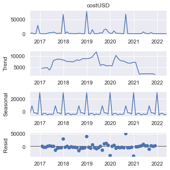

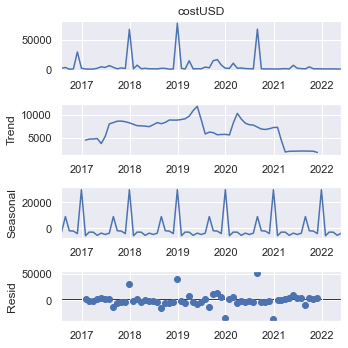

```python
result.plot()
```

```python
df2
```

| modified | user_id | trusted | status_submission | language_id | units | time | cost | costUSD |
| --- | --- | --- | --- | --- | --- | --- | --- | --- |
| 2019-07-16 13:35:20 | 0 | 0 | attribute_submission_pending | vulcan | 5000.0 | 300.0 | 200.0 | 200.00 |
| 2019-07-16 13:35:20 | 0 | 0 | attribute_submission_pending | vulcan | 500.0 | 30.0 | 75.0 | 75.00 |
| 2019-07-16 13:35:20 | 0 | 0 | attribute_submission_pending | vulcan | 50.0 | 10.0 | 50.0 | 50.00 |
| 2019-07-16 13:35:20 | 0 | 0 | attribute_submission_pending | vulcan | 5.0 | 5.0 | 40.0 | 40.00 |
| 2019-08-25 03:00:18 | 1 | 2 | accepted | vulcan | 50000.0 | NaN | 1205.0 | 1205.00 |
| ... | ... | ... | ... | ... | ... | ... | ... | ... |
| 2022-05-10 00:17:52 | 12210 | 1 | accepted | vulcan | 50000.0 | 21600.0 | 1500.0 | 1850.55 |
| 2022-05-10 00:17:52 | 12210 | 1 | accepted | vulcan | 5000.0 | 1800.0 | 120.0 | 148.04 |
| 2022-05-10 00:17:52 | 12210 | 1 | accepted | vulcan | 500.0 | 180.0 | 55.0 | 67.85 |
| 2022-05-10 00:17:52 | 12210 | 1 | accepted | vulcan | 50.0 | 20.0 | 27.0 | 33.31 |
| 2022-05-10 00:17:52 | 12210 | 1 | accepted | vulcan | 5.0 | 2.0 | 9.0 | 11.10 |

59903 rows × 8 columns

```python
df2.reset_index(inplace=True)
```

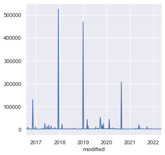

```python
df2.set_index('modified').resample('W')['costUSD'].mean().plot(kind='line')
```

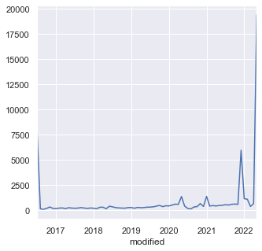

```python
df2.set_index('modified')['costUSD'].resample('M').count().plot(kind='line')
```

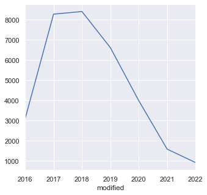

```python
df2.set_index('modified')['costUSD'].resample('Y').mean().plot(kind='line')
```

# Feature Engineering

## Datetime Modeling

```python
df2['year'] = df2.modified.dt.year
df2['month'] = df2.modified.dt.month
df2['day'] = df2.modified.dt.month
```

```python
### Creating a subset of df2 with only values that will be used in baseline model

df3 = df2[['year', 'month', 'day', 'trusted', 'language_id','time','status_submission',
       'units', 'costUSD']].copy()
```

## Outlier Cost USD

Based on "main" feature units, looking for outliers

```python
df3.groupby('units')['costUSD'].describe()
```

| units | count | mean | std | min | 25% | 50% | 75% | max |
| --- | --- | --- | --- | --- | --- | --- | --- | --- |
| 5.0 | 12120.0 | 32.344189 | 377.778113 | 0.00 | 5.000 | 7.00 | 25.000 | 38706.25 |
| 50.0 | 12120.0 | 88.837595 | 1120.756133 | 0.00 | 16.040 | 50.00 | 61.680 | 99999.00 |
| 75.0 | 87.0 | 11.790345 | 27.895760 | 0.25 | 5.000 | 5.00 | 6.585 | 246.74 |
| 150.0 | 87.0 | 21.834483 | 44.050543 | 0.50 | 10.000 | 10.00 | 12.365 | 370.11 |
| 500.0 | 12120.0 | 328.892358 | 9467.388294 | 0.00 | 50.000 | 123.94 | 185.050 | 999909.00 |
| 750.0 | 87.0 | 43.708161 | 83.975306 | 0.74 | 15.000 | 15.00 | 20.000 | 555.16 |
| 1500.0 | 87.0 | 218.095747 | 144.895575 | 2.97 | 105.090 | 250.00 | 250.000 | 925.27 |
| 4500.0 | 87.0 | 436.813448 | 269.886387 | 3.47 | 224.150 | 500.00 | 500.000 | 1300.00 |
| 5000.0 | 12120.0 | 2303.688913 | 104345.215850 | 0.00 | 120.000 | 400.00 | 600.000 | 9999099.00 |
| 18000.0 | 87.0 | 877.667816 | 837.989384 | 3.97 | 458.895 | 900.00 | 900.000 | 5000.00 |
| 50000.0 | 10901.0 | 12285.160230 | 206128.449332 | 0.00 | 400.000 | 1850.55 | 5000.000 | 9999999.00 |

```python
### Units: 75 -150
```

```python
df3.units.value_counts().index
```

```
Float64Index([5000.0, 500.0, 50.0, 5.0, 50000.0, 18000.0, 4500.0, 1500.0,
              750.0, 150.0, 75.0],
             dtype='float64')
```

```python
df3.loc[df3.units==75.0]
```

|  | year | month | day | trusted | language_id | time | status_submission | units | costUSD |
| --- | --- | --- | --- | --- | --- | --- | --- | --- | --- |
| 2627 | 2022 | 5 | 5 | 1 | simlish | 30.0 | test_project_failed_timing | 75.0 | 0.74 |
| 2633 | 2021 | 12 | 12 | 1 | simlish | 30.0 | test_project_failed_timing | 75.0 | 5.00 |
| 2654 | 2021 | 12 | 12 | 1 | simlish | 30.0 | test_project_failed_timing | 75.0 | 6.00 |
| 2660 | 2021 | 12 | 12 | 1 | simlish | 30.0 | test_project_failed_timing | 75.0 | 4.00 |
| 2666 | 2022 | 5 | 5 | 1 | vulcan | 30.0 | test_project_failed_timing | 75.0 | 1.44 |
| ... | ... | ... | ... | ... | ... | ... | ... | ... | ... |
| 54990 | 2021 | 12 | 12 | 1 | simlish | 30.0 | test_project_failed_timing | 75.0 | 5.00 |
| 55006 | 2022 | 5 | 5 | 1 | vulcan | 30.0 | test_project_failed_timing | 75.0 | 24.67 |
| 55012 | 2021 | 12 | 12 | 1 | vulcan | 30.0 | test_project_failed_timing | 75.0 | 50.00 |
| 58566 | 2021 | 12 | 12 | 1 | simlish | 30.0 | test_project_failed_timing | 75.0 | 20.00 |
| 58572 | 2022 | 5 | 5 | 1 | simlish | 30.0 | test_project_failed_timing | 75.0 | 9.91 |

87 rows × 9 columns

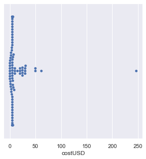

```python
sns.swarmplot(df3.loc[df3.units.isin([75.0]),'costUSD'])
```

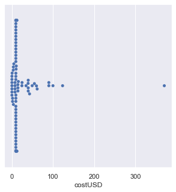

```python
sns.swarmplot(df3.loc[df3.units==150.0,'costUSD'])
```

```python
"""
Removing outliers by category
Looking for a target variable, example: Cost groupby some category and fill with np.nan
values above quantile choosed
"""

def clean_outs(dataframe, group_name, target, n_quant=0.95):

    global df_clean

    df_clean = dataframe

    quantil = df_clean.groupby(f'{group_name}')[f'{target}'].quantile(n_quant)

    groups = quantil.index.to_list()
    quantiles = quantil.to_list()


    for group, quantile in zip(groups, quantiles):

        #print(group, quantile)

        df_clean.loc[(df_clean[f'{group_name}'] == group)&(df_clean[f'{target}'] > quantile)] = np.nan

    return df_clean
```

### Before

```python
df3.groupby('units')['costUSD'].describe()
```

[output not shown]

```python
df3.groupby('language_id')['costUSD'].describe()
```

| language_id | count | mean | std | min | 25% | 50% | 75% | max |
| --- | --- | --- | --- | --- | --- | --- | --- | --- |
| elvish | 45.0 | 3070.322222 | 8266.229771 | 2.00 | 68.0 | 500.00 | 2000.0 | 50000.0 |
| esperanto | 2856.0 | 1312.083428 | 15490.026159 | 0.02 | 5.0 | 50.00 | 200.0 | 500000.0 |
| simlish | 15077.0 | 1913.740956 | 54080.135366 | 0.00 | 15.0 | 74.36 | 350.0 | 5000000.0 |
| vulcan | 41925.0 | 3212.814667 | 114810.687806 | 0.00 | 25.0 | 100.00 | 500.0 | 9999999.0 |

```python
df3.groupby('trusted')['costUSD'].describe()
```

| trusted | count | mean | std | min | 25% | 50% | 75% | max |
| --- | --- | --- | --- | --- | --- | --- | --- | --- |
| 0 | 708.0 | 665.484364 | 2495.437747 | 0.50 | 25.0 | 100.0 | 387.90 | 50000.00 |
| 1 | 56540.0 | 2919.179533 | 102788.029098 | 0.00 | 20.0 | 100.0 | 493.48 | 9999999.00 |
| 2 | 2655.0 | 721.140629 | 4367.802684 | 0.77 | 20.0 | 75.0 | 300.00 | 123369.67 |

### After

```python
# i've cleaned up by importance order.
df3 = clean_outs(dataframe = df3, group_name='units', target='costUSD', n_quant=0.95)
```

```python
df3.groupby('units')['costUSD'].describe()
```

| units | count | mean | std | min | 25% | 50% | 75% | max |
| --- | --- | --- | --- | --- | --- | --- | --- | --- |
| 5.0 | 11600.0 | 17.680570 | 23.019423 | 0.00 | 5.0000 | 6.17 | 24.6700 | 100.00 |
| 50.0 | 11514.0 | 48.514772 | 43.602178 | 0.00 | 15.0000 | 49.35 | 61.6800 | 223.09 |
| 75.0 | 82.0 | 7.152439 | 7.188741 | 0.25 | 5.0000 | 5.00 | 6.1275 | 30.00 |
| 150.0 | 82.0 | 13.733171 | 13.374358 | 0.50 | 10.0000 | 10.00 | 12.0000 | 61.68 |
| 500.0 | 11598.0 | 132.385172 | 112.229199 | 0.00 | 49.3500 | 120.00 | 180.0000 | 500.00 |
| 750.0 | 83.0 | 28.924217 | 42.647514 | 0.74 | 15.0000 | 15.00 | 19.0000 | 200.00 |
| 1500.0 | 83.0 | 197.898554 | 107.102734 | 2.97 | 86.7550 | 250.00 | 250.0000 | 400.00 |
| 4500.0 | 82.0 | 394.744756 | 211.540779 | 3.47 | 192.9900 | 500.00 | 500.0000 | 863.59 |
| 5000.0 | 11541.0 | 417.697923 | 381.318581 | 0.00 | 100.0000 | 370.11 | 500.0000 | 2000.00 |
| 18000.0 | 82.0 | 711.658537 | 364.115823 | 3.97 | 445.5975 | 900.00 | 900.0000 | 1200.00 |
| 50000.0 | 10370.0 | 2586.370203 | 2573.380399 | 0.00 | 350.0000 | 1500.00 | 5000.0000 | 12336.97 |

```python
df3 = clean_outs(dataframe = df3, group_name='language_id', target='costUSD', n_quant=0.98)
```

```python
df3.groupby('language_id')['costUSD'].describe()
```

| language_id | count | mean | std | min | 25% | 50% | 75% | max |
| --- | --- | --- | --- | --- | --- | --- | --- | --- |
| elvish | 32.0 | 568.453125 | 1018.018940 | 2.00 | 36.25 | 125.00 | 572.97 | 5000.0 |
| esperanto | 2801.0 | 546.618508 | 1370.382132 | 0.02 | 5.00 | 50.00 | 152.65 | 5000.0 |
| simlish | 14252.0 | 456.956542 | 1108.583472 | 0.00 | 12.39 | 55.00 | 250.00 | 5000.0 |
| vulcan | 39077.0 | 474.820756 | 1076.426270 | 0.00 | 20.00 | 86.36 | 357.77 | 6000.0 |

```python
df3 = clean_outs(dataframe = df3, group_name='trusted', target='costUSD', n_quant=0.98)
```

```python
df3.groupby('trusted')['costUSD'].describe()
```

| trusted | count | mean | std | min | 25% | 50% | 75% | max |
| --- | --- | --- | --- | --- | --- | --- | --- | --- |
| 0.0 | 672.0 | 361.590774 | 699.456154 | 0.50 | 25.00 | 82.595 | 308.42 | 4000.0 |
| 1.0 | 52731.0 | 462.087563 | 1075.733537 | 0.00 | 19.83 | 75.000 | 308.42 | 5000.0 |
| 2.0 | 2513.0 | 273.956896 | 531.798780 | 0.77 | 20.00 | 60.000 | 250.00 | 3900.0 |

```python
df3.describe([0.5,0.75,0.8,0.85,0.9,0.92,0.95,0.99,1]).round()
```

|  | year | month | day | trusted | time | units | costUSD |
| --- | --- | --- | --- | --- | --- | --- | --- |
| count | 55916.0 | 55916.0 | 55916.0 | 55916.0 | 49712.0 | 55916.0 | 55916.0 |
| mean | 2020.0 | 6.0 | 6.0 | 1.0 | 1720.0 | 9383.0 | 452.0 |
| std | 2.0 | 3.0 | 3.0 | 0.0 | 5384.0 | 18101.0 | 1054.0 |
| min | 2016.0 | 1.0 | 1.0 | 0.0 | 0.0 | 5.0 | 0.0 |
| 50% | 2021.0 | 5.0 | 5.0 | 1.0 | 50.0 | 500.0 | 75.0 |
| 75% | 2022.0 | 8.0 | 8.0 | 1.0 | 180.0 | 5000.0 | 300.0 |
| 80% | 2022.0 | 10.0 | 10.0 | 1.0 | 300.0 | 5000.0 | 500.0 |
| 85% | 2022.0 | 11.0 | 11.0 | 1.0 | 1800.0 | 50000.0 | 555.0 |
| 90% | 2022.0 | 12.0 | 12.0 | 1.0 | 1800.0 | 50000.0 | 1000.0 |
| 92% | 2022.0 | 12.0 | 12.0 | 1.0 | 1800.0 | 50000.0 | 1480.0 |
| 95% | 2022.0 | 12.0 | 12.0 | 1.0 | 21600.0 | 50000.0 | 3000.0 |
| 99% | 2022.0 | 12.0 | 12.0 | 2.0 | 21600.0 | 50000.0 | 5000.0 |
| 100% | 2022.0 | 12.0 | 12.0 | 2.0 | 21600.0 | 50000.0 | 5000.0 |
| max | 2022.0 | 12.0 | 12.0 | 2.0 | 21600.0 | 50000.0 | 5000.0 |

```python
df3.costUSD.describe([0,0.1,0.2,0.25,0.5]).round()
```

```
count    55916.0
mean       452.0
std       1054.0
min          0.0
0%           0.0
10%          5.0
20%         10.0
25%         20.0
50%         75.0
max       5000.0
Name: costUSD, dtype: float64
```

```python
# Low limit for cost USD

df3.loc[df3.costUSD<5,'costUSD']=np.nan
```

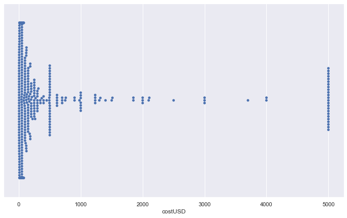

```python
plt.figure(figsize = ( 12, 7))
sns.swarmplot(df3.costUSD.sample(500))
```

```python
df3.isnull().sum()
```

```
year                  3987
month                 3987
day                   3987
trusted               3987
language_id           3987
time                 10191
status_submission     3987
units                 3987
costUSD               8289
dtype: int64
```

```python
df3.dropna(inplace=True)
```

```python
df3.isnull().sum()
```

```
year                 0
month                0
day                  0
trusted              0
language_id          0
time                 0
status_submission    0
units                0
costUSD              0
dtype: int64
```